# Analyzing yeast RNAseq data

### Visualizing data

We can look at the abundances for any given gene with the following code:

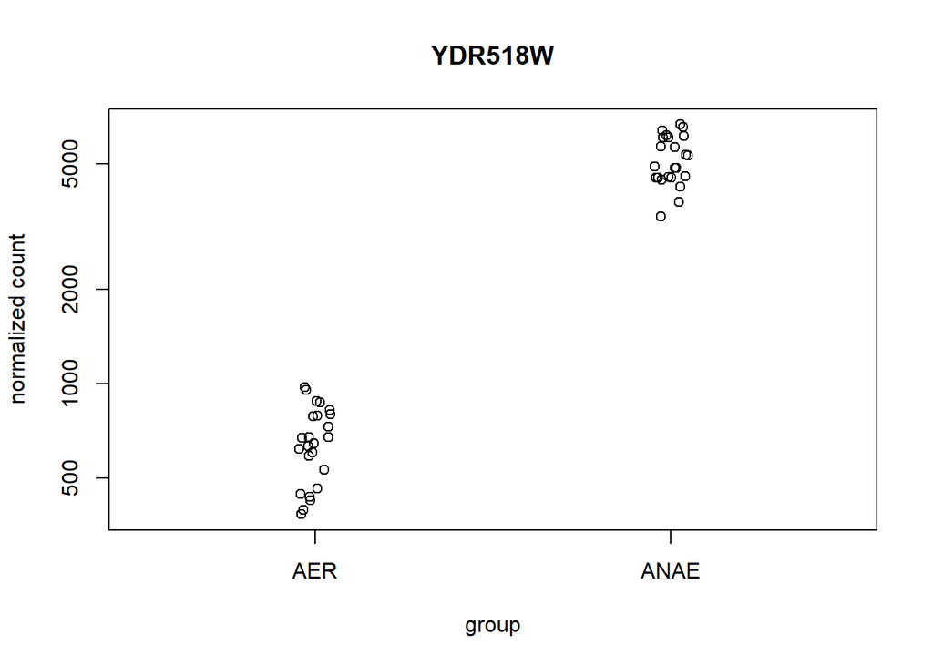

```r
# Looking at gene YDR518W
geneID = "YDR518W"
plotCounts(dds, gene=geneID, intgroup="oxy")
```

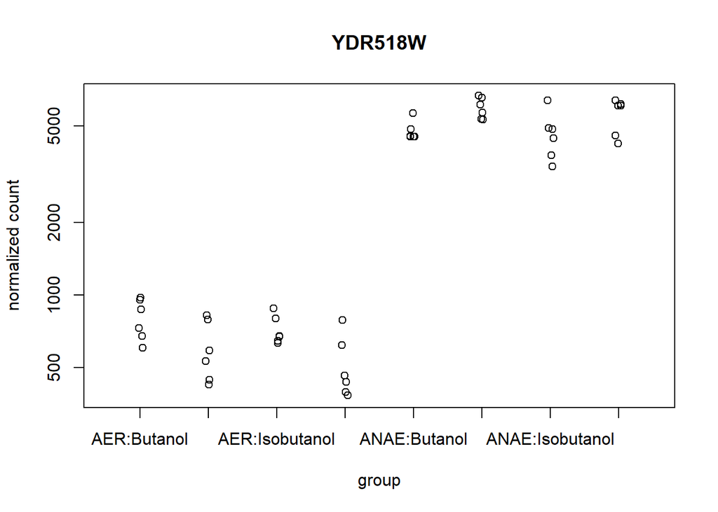

```r
# We can even split the data by aero/aner + agent to see if the increased/decreased expression level is specific to a certain agent
plotCounts(dds, gene=geneID, intgroup=c("oxy", "agent"))
```

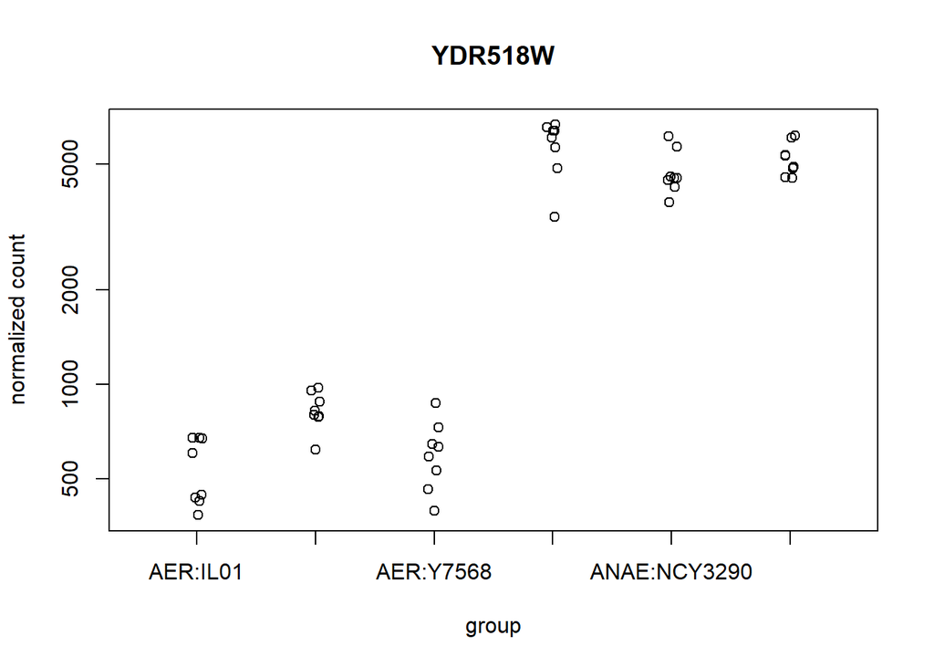

```r
# Or specific to a certain strain?
plotCounts(dds, gene=geneID, intgroup=c("oxy", "Strain"))
```

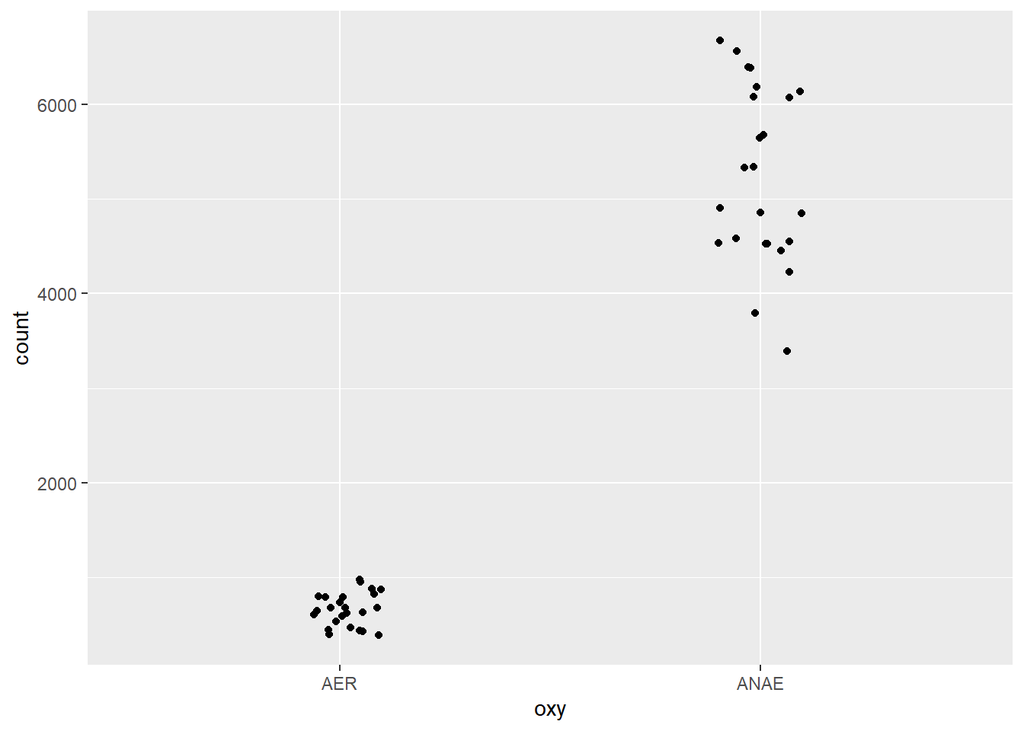

```r
# Let's make these plots nicer with ggplot. For this, we will capture the data returned by "plotCounts" and then use ggplot to perform the actual ploting:
d <- plotCounts(dds, gene=geneID, intgroup=c("oxy"), returnData=TRUE)
ggplot(d, aes(x=oxy, y=count) ) + geom_point(position=position_jitter(w=0.1,h=0))
```

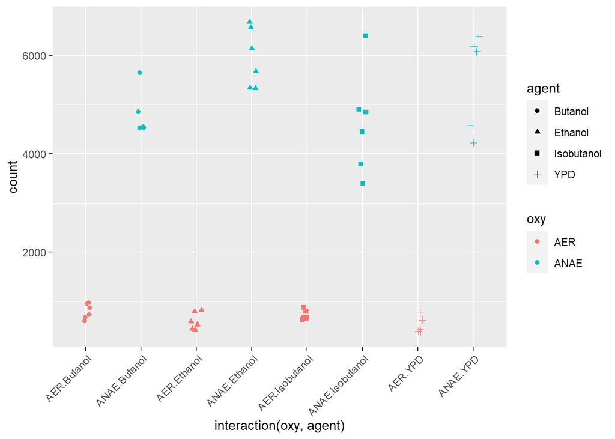

```r
d <- plotCounts(dds, gene=geneID, intgroup=c("oxy", "agent"), returnData=TRUE)
ggplot(d, aes(x=interaction(oxy,agent), y=count, color=oxy, shape=agent)) +
  geom_point(position=position_jitter(w=0.1,h=0)) +
  theme(axis.text.x=element_text(angle=45,hjust=1))
```

## Exercise:

1. The 2006 study found that only 5 out of 27 genes tested confer an advantage for anaerobic growth. Are these 5 genes significantly more highly expressed in anaerobic vs aerobic condition in this new experiment? The list of genes is: eug1, izh2, plb2, ylr413w and yor012w. You can convert the gene name into its corrsponding systematic ID by searching for it on: https://www.yeastgenome.org/

For example, the ID for eug1 in this experiment is: YDR518W

2. The main result from the 2006 study was that many genes with increased expression level under anaerobic conditions did not contribute to the fitness/survival of yeast when grown anaerobically. One possible explanation for this surprising result is that some of the genes in the list used in 2006 are not really over-expressed under anaerobic growth (false positives). One such gene is **muc1**. Does the new data confirm that muc1 is over-expressed under anaerobic growth? How about the gene **ysr3**?

## Data quality control and clustering

This step can be extremely useful to spot problems with the data. For example, if a sample was incorrectly labeled or switched (these things happen more frequently than they should in the real world…). Here, we will perform a clustering of the samples to detect any problem.

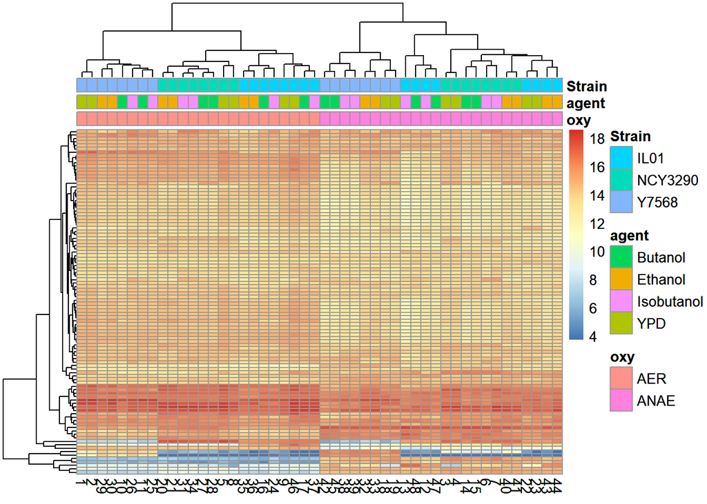

```r
library("pheatmap")
library("vsn")

# Normalizing the data
blind = F
vsd <- vst(dds, blind=blind)

# We will use the top 100 genes with the highest expression level to perform the clustering:
nbTopGenes = 100
select <- order(rowMeans(counts(dds,normalized=TRUE)), decreasing=TRUE)[1:nbTopGenes]
df <- as.data.frame(colData(dds)[,c("oxy","agent", "Strain")])
ph <- pheatmap(assay(vsd)[select,], cluster_rows=T, show_rownames=F, cluster_cols=T, annotation_col=df)
ph
```

In this heatmap, each row represent the expression pattern of a gene across all the samples (samples are in columns). Which variable (Strain, agent or oxy) has the most clustering/predictive power? Do you see any odd sample?

## Gene ontology analysis.

Genes can be annotated based on their function. A massive effort to annotate the function of genes is the Gene Ontology project: http://geneontology.org/

Gene ontology categories can be of three types: Molecular Function (MF), Biological Process (BP), or Cellular Component (CC). Our eug1 gene is also a member of GO:0005783 (endoplasmic reticulum) in the Cellular Component ontology.

Note that not all genes are assigned a functional category. For many genes, the function that they perform is still unknown.

It is often desirable to find if certain functional categories are over-represented among genes deferentially expressed in an experiment. For example here, we could be interested in finding which types of genes tend to be diferentially expressed in response to anaerobic growth. This type of analysis is called a **GO enrichement** analysis. Here is a short road map about how to perform this analysis:

```r
library("topGO")
library("org.Sc.sgd.db")


# The main information needed for the GO enrichement analysis is a list of values summarizing the experiment for each gene (what is called the "gene universe")
# The value can be anything, but what is typically used is the p-value on the differential expression test (although the log fold change is also used sometimes)
# The goal is to create a vector with as many elements as there are genes in the analysis. The values inside the vector are the p-values and the names of the elements in the vector are the gene names.
# The following short function creates this vector for us:
getGeneUniverse <- function(deseqRes){
  vgs = as.numeric(deseqRes$pvalue)
  names(vgs) = rownames(deseqRes)
  vgs
}

# The sel_pval function is to be used for some enrichment analysis. Some tests use a hard cutt-off to generate list of genes deferentially expressed. In this case, the cutoff would be a p-value of 0.05.
# When using this strategy, the GO enrichment is done as follows:
# - Let's assume that the gene universe is 10,000 genes.
# - 2,000 of these genes are deferentially expressed (with p-value cutoff of 0.05)
# - 500 of the 10,000 genes are annotated as belonging to GO:00001 (a fictional Gene Ontology category)
# - 400 of the 2,000 belong to GO:00001
# Is GO:00001 over-represented among deferentially expressed genes?
# (The null expectation would be: 500*0.2 = 100)
# This can be tested with a simple Fisher test.
# Note that more sophisticated methods (Such as Kolmogorov–Smirnov) are also available and circumvent the use of arbitrary cutoffs
sel_pval <- function(allScore){ return(allScore < 0.05)}

geneUniverse = getGeneUniverse(DESeq2res)

dGO <- as.data.frame(org.Sc.sgdGO)
geneID2GO <- list()
for(geneID in unique(dGO$systematic_name)){
  geneID2GO[[geneID]] <- dGO$go_id[which(dGO$systematic_name==geneID)]
}

ontology <- "BP"
go2genes <- annFUN.gene2GO(whichOnto = ontology, gene2GO = geneID2GO)


# Preparing the topGO analysis for the Biological Process (BP) ontology:
GOdata = new("topGOdata", description="diff expr GO test", ontology= ontology,
             allGenes = geneUniverse, geneSel = sel_pval,
             nodeSize = 10,
             annot = annFUN.GO2genes,
             GO2genes=go2genes)

allGO = usedGO(object = GOdata)
GOresult = runTest(GOdata, statistic = "ks", algorithm = "elim")

allRes <- GenTable(GOdata, pval = GOresult, topNodes = length(allGO))

kable(allRes[1:20,])
```

| GO.ID | Term | Annotated | Significant | Expected | pval |
| --- | --- | --- | --- | --- | --- |
| GO:0002181 | cytoplasmic translation | 180 | 174 | 144.11 | < 1e-30 |
| GO:0000462 | maturation of SSU-rRNA from tricistronic… | 104 | 101 | 83.27 | 1.3e-13 |
| GO:0000027 | ribosomal large subunit assembly | 43 | 43 | 34.43 | 2.5e-10 |
| GO:0000463 | maturation of LSU-rRNA from tricistronic… | 52 | 48 | 41.63 | 3.5e-10 |
| GO:0042273 | ribosomal large subunit biogenesis | 127 | 122 | 101.68 | 1.6e-08 |
| GO:0000447 | endonucleolytic cleavage in ITS1 to sepa… | 44 | 43 | 35.23 | 4.4e-07 |
| GO:0000480 | endonucleolytic cleavage in 5’-ETS of tr… | 33 | 32 | 26.42 | 5.2e-07 |
| GO:0000472 | endonucleolytic cleavage to generate mat… | 34 | 33 | 27.22 | 8.9e-07 |
| GO:0000466 | maturation of 5.8S rRNA from tricistroni… | 91 | 86 | 72.86 | 9.5e-07 |
| GO:0006407 | rRNA export from nucleus | 16 | 16 | 12.81 | 1.9e-06 |
| GO:0015986 | proton motive force-driven ATP synthesis | 18 | 16 | 14.41 | 2.2e-05 |
| GO:0006364 | rRNA processing | 280 | 264 | 224.18 | 4.4e-05 |
| GO:0000028 | ribosomal small subunit assembly | 26 | 24 | 20.82 | 4.6e-05 |
| GO:0030488 | tRNA methylation | 24 | 22 | 19.22 | 5.5e-05 |
| GO:0120009 | intermembrane lipid transfer | 21 | 20 | 16.81 | 5.9e-05 |
| GO:0006450 | regulation of translational fidelity | 31 | 28 | 24.82 | 8.6e-05 |
| GO:0048278 | vesicle docking | 34 | 32 | 27.22 | 0.00013 |
| GO:0034727 | piecemeal microautophagy of the nucleus | 41 | 40 | 32.83 | 0.00018 |
| GO:0001732 | formation of cytoplasmic translation ini… | 10 | 10 | 8.01 | 0.00020 |
| GO:0043328 | protein transport to vacuole involved in… | 28 | 24 | 22.42 | 0.00022 |

### Question:

Based on the name/description of these functional categories, can you identify some that are clearly related to aerobic vs anaerobic growth? Is the functional category **cellular respiration** significantly over/under represented among diferentially expressed genes?

Now looking at Cellular Components:

```r
ontology <- "CC"

go2genes <- annFUN.gene2GO(whichOnto = ontology, gene2GO = geneID2GO)
GOdata = new("topGOdata", description="diff expr GO test", ontology= ontology,
             allGenes = geneUniverse, geneSel = sel_pval,
             nodeSize = 10,
             annot = annFUN.GO2genes,
             GO2genes=go2genes)

allGO = usedGO(object = GOdata)
GOresult = runTest(GOdata, statistic = "KS", algorithm = "elim")

allRes <- GenTable(GOdata, pval = GOresult, topNodes = length(allGO))

kable(allRes[1:10,])
```

| GO.ID | Term | Annotated | Significant | Expected | pval |
| --- | --- | --- | --- | --- | --- |
| GO:0030686 | 90S preribosome | 90 | 87 | 72.12 | < 1e-30 |
| GO:0022625 | cytosolic large ribosomal subunit | 80 | 78 | 64.11 | < 1e-30 |
| GO:0005730 | nucleolus | 289 | 262 | 231.59 | 1.0e-15 |
| GO:0022627 | cytosolic small ribosomal subunit | 59 | 55 | 47.28 | 1.9e-14 |
| GO:0032040 | small-subunit processome | 53 | 53 | 42.47 | 3.5e-12 |
| GO:0030687 | preribosome, large subunit precursor | 62 | 60 | 49.68 | 8.5e-11 |
| GO:0000839 | Hrd1p ubiquitin ligase ERAD-L complex | 12 | 12 | 9.62 | 8.6e-07 |
| GO:0030688 | preribosome, small subunit precursor | 23 | 23 | 18.43 | 2.3e-06 |
| GO:0005737 | cytoplasm | 4349 | 3546 | 3485.11 | 3.0e-05 |
| GO:0005736 | RNA polymerase I complex | 12 | 12 | 9.62 | 3.4e-05 |